# Pearson Audition Project

Tomasz Dąbrowski

20th of October, 2016

## Introduction

This document presents exploratoy research of Pearson’s e-learning platform data. It will contain research hypothesis, descriptive statisitics, hypothesis testing, and others.

### Loading data

Let’s load a data from working directory and then take a look how it looks like.

```r
dt <- dt <- read.csv("data.csv", header = T, sep = ",")
head(dt)
```

```
##   learner_id country in_course     unit avg_score completion inv_rate
## 1         39      PL         t        1     0.200      0.100    0.000
## 2         39      PL         t        3     1.000      0.087    0.000
## 3         39      PL         t REVIEW 2     0.100      0.273    0.000
## 4         41      PL         t        1     0.877      0.350    0.381
## 5         41      PL         t        3     0.000      0.087    0.000
## 6         41      PL         t        5     0.000      0.087    1.000
```

Let’s see how many variables and observations are in the spreadsheet.

```r
dim(dt)
```

```
## [1] 81432     7
```

What are the types of the variables?

```r
str(dt)
```

```
## 'data.frame':    81432 obs. of  7 variables:
##  $ learner_id: int  39 39 39 41 41 41 41 802 802 802 ...
##  $ country   : Factor w/ 87 levels "","AD","AF","AG",..: 62 62 62 62 62 62 62 1 1 1 ...
##  $ in_course : Factor w/ 2 levels "f","t": 2 2 2 2 2 2 2 2 2 2 ...
##  $ unit      : Factor w/ 17 levels "1","10","11",..: 1 6 14 1 6 8 14 1 5 6 ...
##  $ avg_score : num  0.2 1 0.1 0.877 0 0 0 0.954 0.877 0.883 ...
##  $ completion: num  0.1 0.087 0.273 0.35 0.087 0.087 0.182 1 1 0.739 ...
##  $ inv_rate  : num  0 0 0 0.381 0 1 0 0 0 0 ...
```

### Understanding vriables

All right, we have some information about data. It’s time to make some assumptions. Which varaibles look interesting? They are described in the attached document. Let’s have them here…

- **learner** id : anonymized student identifier
- **country** : country code of the student
- **in_course** : “t” if the student belongs to course taught by a teacher (as opposed to studying alone)
- **unit** : number or name of a unit (chapter) in the workbook
- **avg_score** : average percentage score on all activities within a given unit
- **completion** : the percentage of activities completed in a given unit, out of all activities available in that unit
- **inv_rate** : This is the extent to which a student deviates from the suggested order of activities by the pedagogy experts within a given unit. A value of zero indicates no departure from the suggested order, a value of one indicates a complete reversal of the order.

The **country** variable looks promising. We will be able to compare performance of students across different countries. Thanks to **in_course** variable, we will assesss efficiency of teachers. **unit**, **avg_score** and **completion** variables should tell us something about difficulty of certain units. **inv_rate** seems to be very interesting. Do ‘rebel’ students perform better than ‘regular’ students? Are some countries more rebelious than others? Does teacher presence impact the way students learn?

### Exploring data

1. Let’s load some useful packages now.

```r
library(plyr)
library(ggplot2)
```

#### Question 1: Which units are the hardest? Which have the smallest completion rate?

```r
levels(dt$unit)
```

```
##  [1] "1"              "10"             "11"             "12"
##  [5] "2"              "3"              "4"              "5"
##  [9] "6"              "7"              "8"              "9"
## [13] "REVIEW 1"       "REVIEW 2"       "REVIEW 3"       "REVIEW 4"
## [17] "VIDEO PODCASTS"
```

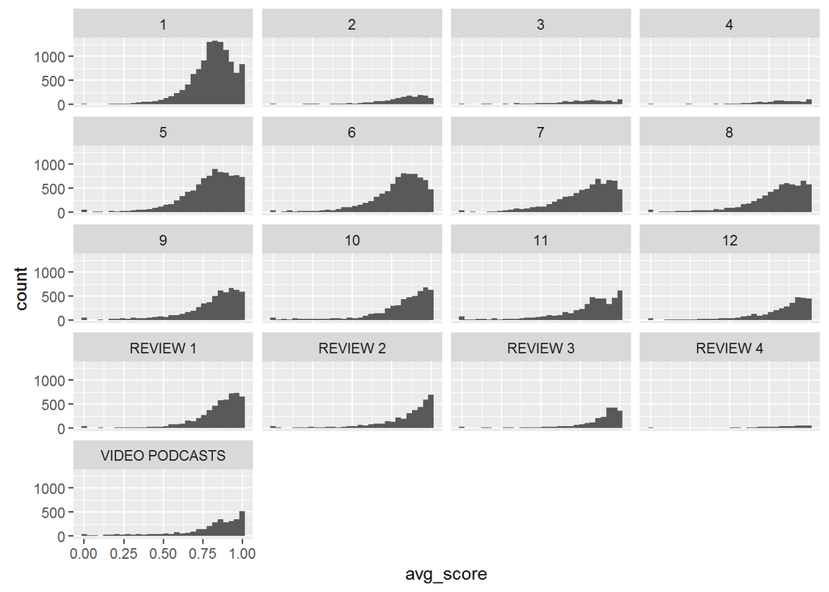

```r
levels(dt$unit) <- c("1", "2", "3", "4", "5", "6", "7", "8", "9", "10", "11", "12", "REVIEW 1", "REVIEW 2", "REVIEW 3", "REVIEW 4", "VIDEO PODCASTS")

qplot(x = avg_score, data = dt) +
  facet_wrap(~unit, ncol = 4)
```

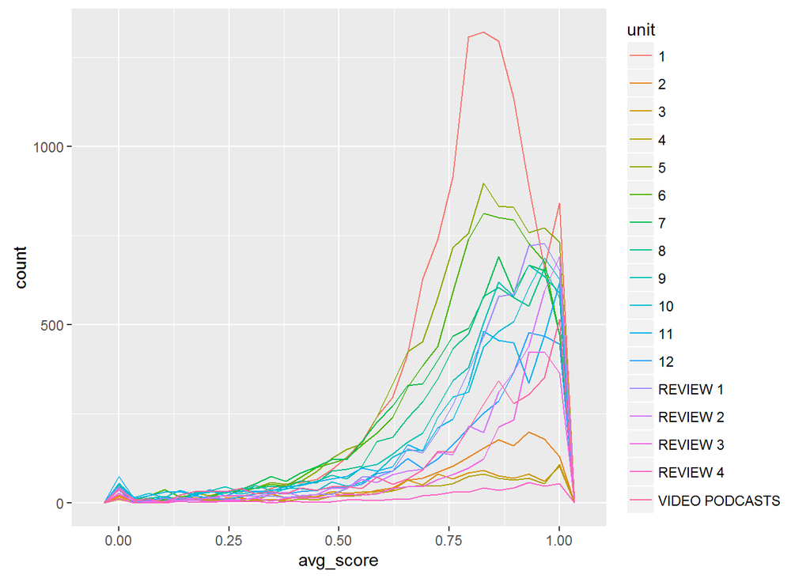

```r
qplot(x = avg_score, data = dt, geom = "freqpoly", color = unit)
```

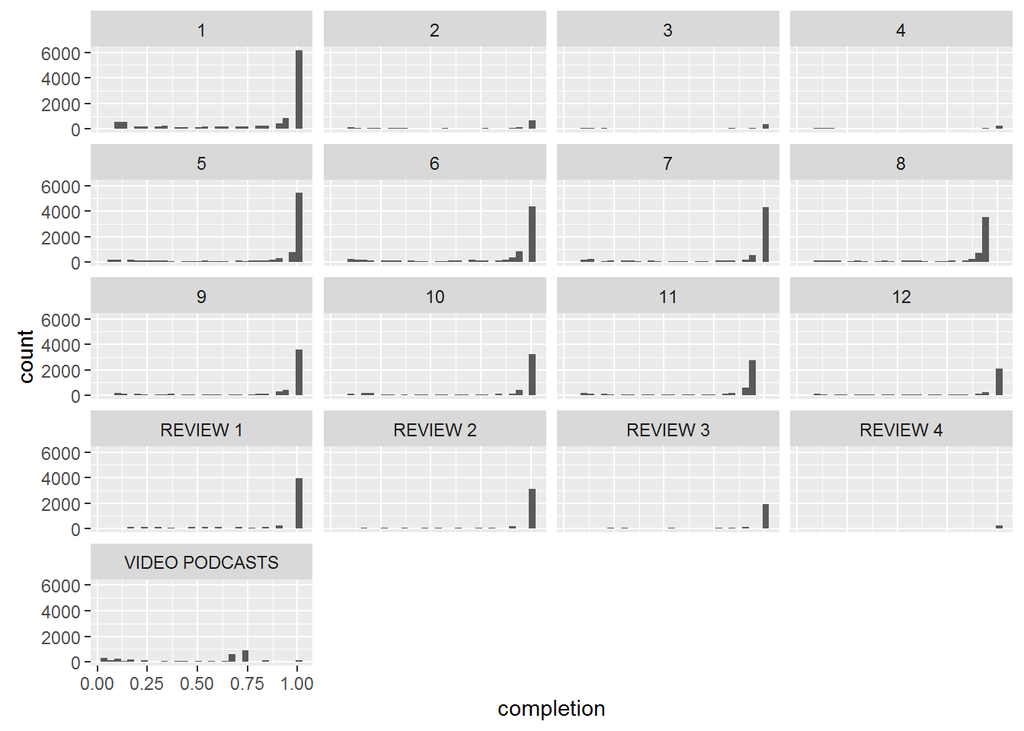

```r
qplot(x = completion, data = dt) +
  facet_wrap(~unit, ncol = 4)
```

#### Question 2: Which country performs the best?

We have 87 countries. How to compare the scores among them? We need to average the average scores of students in these countries. We will choose only countries that have more than 500 observations.

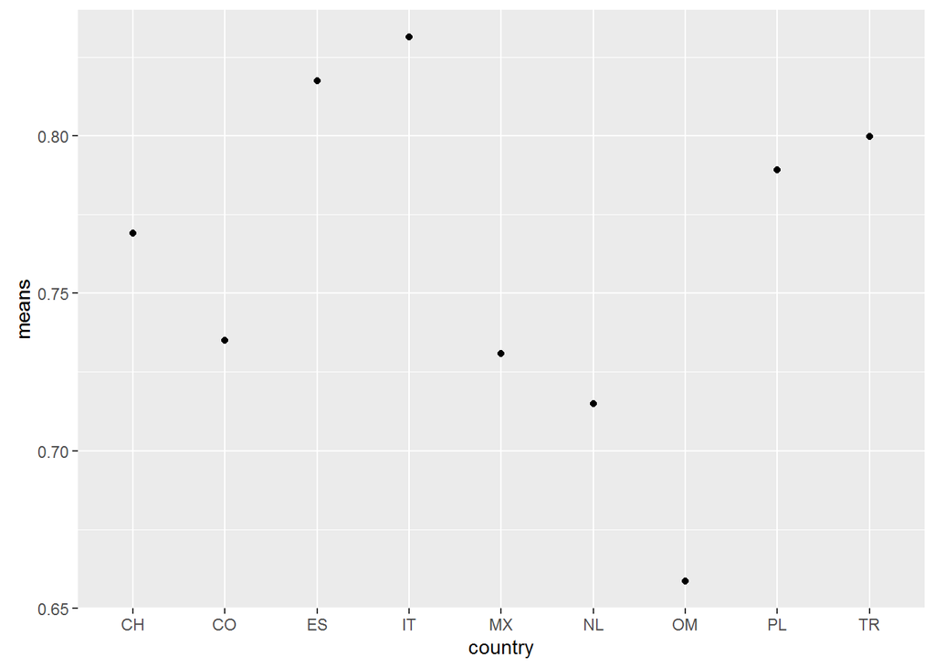

```r
#install.packages("tidyr")
library(tidyr)
library(dplyr)

dt2 <- data.frame(dt$country, dt$avg_score)
colnames(dt2) <- c("country", "avg_score")

dt2 <- subset(dt2, dt$country != "") #subet of obs. with known countries
dt3 <- dt2 %>%
        group_by(country) %>%
        mutate(id = row_number()) %>%
        spread(country, avg_score) %>%
        select(-id)

stud_num <- apply(dt3, 2, function(x) length(which(!is.na(x)))) #Variable: How many non-NA's is there in a column?

means <- apply(dt3, 2, function(x) mean(x, na.rm = T)) #Variable: Means of average scores for every country
sd <- apply(dt3, 2, function(x) sd(x, na.rm = T))#Variable: Standard Deviation from the mean

dt5 <- data.frame(means, stud_num, sd)#Data frame with new variables

dt6 <- dt5[dt5$stud_num > 500, ] #Data frame with countries that have more than 500 observations
dt6$country <- rownames(dt6) #add Country as variable
rownames(dt6) <- 1:9 #Remove country names from rownames()

ggplot(data = dt6) +
  geom_point(mapping = aes(x = country, y = means)) #mean avg. scores for every country
```

We can observe that countries with the best mean scores are Italy (m = 0.83), Spain (m = 0.82) and Turkey (m = 0.80). Oman (m = 0.66) was the worst from the measured countries.

#### 3. Does having a teacher improve performance?

```r
summary(dt$in_course)
```

```
##     f     t
##  6100 75332
```

```r
reg <- lm(avg_score~in_course, data = dt)
summary(reg)
```

```
##
## Call:
## lm(formula = avg_score ~ in_course, data = dt)
##
## Residuals:
##      Min       1Q   Median       3Q      Max
## -0.79513 -0.07413  0.04687  0.13787  0.24483
##
## Coefficients:
##             Estimate Std. Error t value Pr(>|t|)
## (Intercept) 0.755167   0.002462  306.71   <2e-16 ***
## in_courset  0.039963   0.002560   15.61   <2e-16 ***
## ---
## Signif. codes:  0 '***' 0.001 '**' 0.01 '*' 0.05 '.' 0.1 ' ' 1
##
## Residual standard error: 0.1923 on 81428 degrees of freedom
##   (2 observations deleted due to missingness)
## Multiple R-squared:  0.002984,   Adjusted R-squared:  0.002972
## F-statistic: 243.7 on 1 and 81428 DF,  p-value: < 2.2e-16
```

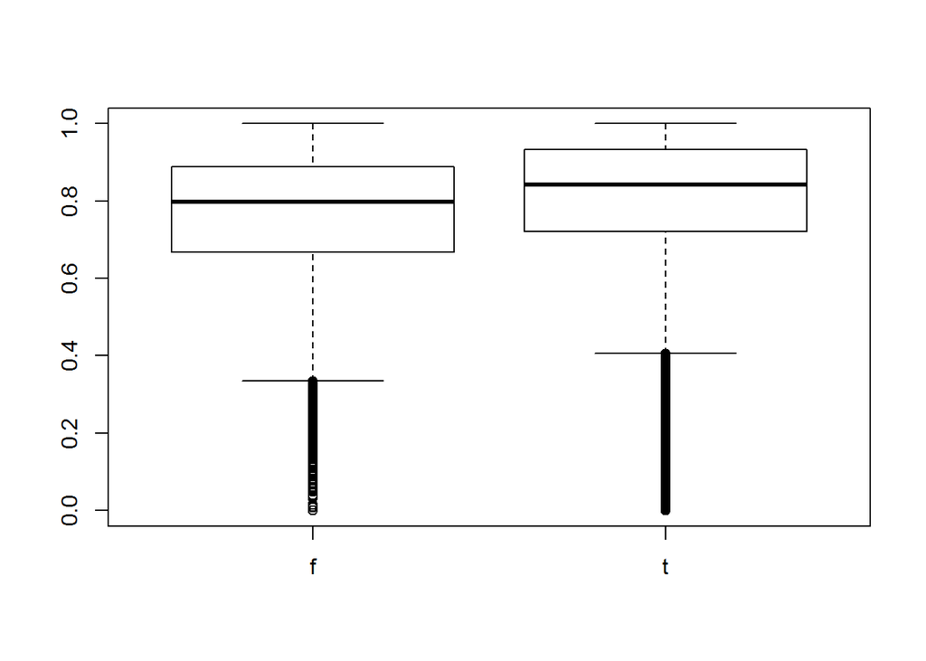

```r
plot(dt$in_course, dt$avg_score)
```

As we can see from the plots above, tutored group has significantly higher scores than group without teacher (p < .001).

#### 4. Does higher inversion rate improve performance?

```r
summary(dt$inv_rate)
```

```
##    Min. 1st Qu.  Median    Mean 3rd Qu.    Max.
## 0.00000 0.00000 0.00000 0.04416 0.02300 1.00000
```

```r
reg2 <- lm(avg_score~inv_rate, data = dt)
summary(reg2)
```

```
##
## Call:
## lm(formula = avg_score ~ inv_rate, data = dt)
##
## Residuals:
##      Min       1Q   Median       3Q      Max
## -0.79666 -0.07366  0.04734  0.13734  0.30578
##
## Coefficients:
##               Estimate Std. Error t value Pr(>|t|)
## (Intercept)  0.7966608  0.0007206 1105.52   <2e-16 ***
## inv_rate    -0.1024428  0.0058050  -17.65   <2e-16 ***
## ---
## Signif. codes:  0 '***' 0.001 '**' 0.01 '*' 0.05 '.' 0.1 ' ' 1
##
## Residual standard error: 0.1922 on 81428 degrees of freedom
##   (2 observations deleted due to missingness)
## Multiple R-squared:  0.00381,    Adjusted R-squared:  0.003798
## F-statistic: 311.4 on 1 and 81428 DF,  p-value: < 2.2e-16
```

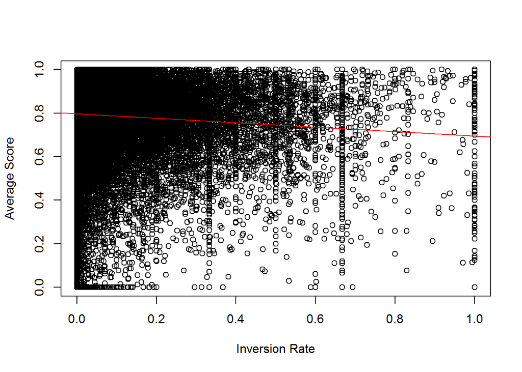

```r
plot(dt$inv_rate, dt$avg_score, xlab = "Inversion Rate", ylab = "Average Score")
abline(reg2, col="red")
```

As we can see from the regression line above, inverting designed learning order does not help better performance. Students should be encouraged to stay in track.